# Analysis of missing data patterns

Vincent Bagilet, Léo Zabrocki

July 30, 2020

In this document, we analyse missing data patterns in the dataset.

First of all, we noticed that there are some issues with the dataset and therefore, for now, restrict the dataset to get rid off these issues. In particular, we do not have any pollution data for 2014 nor for NO in 2015 and very few observations for PMs in 2019. These issue do not come from actual missing data but are due to issue with the package we used to access the pollution data. These data are available through the EEA interface.

```r
data <- data_imputation %>%
  mutate(year = lubridate::year(date)) %>%
  filter(year != 2014) %>%
  filter(!(year == 2015 & pollutant == "no")) %>%
  filter(!(year == 2019 & str_sub(pollutant, 1, 2) == "pm")) %>%
  select(-year)

# rm(data_imputation)
```

# Location of measurement stations

The stations considered are located in the 17 biggest largest in France:

```r
metadata_pollution %>%
  count(city) %>%
  kable(col.names = c("City", "Number of stations"))
```

# Missing data patterns in the sample

Here, we investigate whether missing pollutant concentration data varies across different dimentions.

The overall share of missing values is 0.046308.

## Across pollutants

We can break this down by pollutant.

```r
data %>%
  hist_missing_by(grouping_var = "pollutant")
```

## Across locations

We look weather missingness patterns vary across cities.

[figure not shown]

```r
data %>%
  hist_missing_by(grouping_var = "site_area")
```

```r
data %>%
  hist_missing_by(grouping_var = "site_type")
```

```r
data %>%
  hist_missing_by(grouping_var = "elevation")
```

```r
data %>%
  hist_missing_by(grouping_var = "latitude")
```

## Across dates and time

```r
data %>%
  mutate(year = year(date)) %>%
  hist_missing_by(grouping_var = "year")
```

We look at whether this variation comes more from some pollutants than others.

```r
data %>%
  mutate(year = year(date)) %>%
  group_by(pollutant, year) %>%
  summarise(share_missing = sum(is.na(concentration))/n()) %>%
  arrange(share_missing) %>%
  ggplot() +
  geom_col(aes(x = factor(year), y = share_missing, fill = pollutant), position = "dodge") +
  labs(title = "Share of missing PM10 concentration data by year and pollutant", x = "Year", y =  "Share of missing PM10 concentration data") +
  ylim(0, 1)
```

```r
data %>%
  mutate(year_month = paste(year(date), str_pad(month(date), 2, pad = 0))) %>%
  hist_missing_by(grouping_var = "year_month")
```

We now investigate whether the share of missing data varies across month of the year, day of the month and day of the week. There does not seem to be huge variations.

### Month

```r
data %>%
  mutate(month = factor(month(date))) %>%
  hist_missing_by(grouping_var = "month")

data %>%
  mutate(
    year = factor(year(date)),
    month = factor(month(date))
  ) %>%
  hist_missing_by(grouping_var = "month", facet_var = "year")
```

### Day of the month

```r
data %>%
  mutate(day_of_month = factor(day(date))) %>%
  hist_missing_by(grouping_var = "day_of_month")

data %>%
  mutate(
    year = factor(year(date)),
    day_of_month = factor(day(date))
  ) %>%
  hist_missing_by(grouping_var = "day_of_month", facet_var = "year")

data %>%
  mutate(
    month = factor(month(date)),
    day_of_month = factor(day(date))
  ) %>%
  hist_missing_by(grouping_var = "day_of_month", facet_var = "month")
```

### Day of the week

```r
data %>%
  mutate(day_in_week = factor(wday(date))) %>%
  hist_missing_by(grouping_var = "day_in_week")

data %>%
  mutate(
    year = factor(year(date)),
    day_in_week = factor(wday(date))
  ) %>%
  hist_missing_by(grouping_var = "day_in_week", facet_var = "year")

data %>%
  mutate(
    month = factor(month(date)),
    day_in_week = factor(wday(date))
  ) %>%
  hist_missing_by(grouping_var = "day_in_week", facet_var = "month")
```

### Hour of the day

Now we investigate whether there are some variation in missingness patterns across time.

```r
data %>%
  mutate(hour = factor(hour(date))) %>%
  hist_missing_by(grouping_var = "hour")
```

```r
data %>%
  mutate(hour = factor(hour(date))) %>%
  hist_missing_by(grouping_var = "hour", facet_var = "pollutant")
```

## Across weather patterns

### Temperature

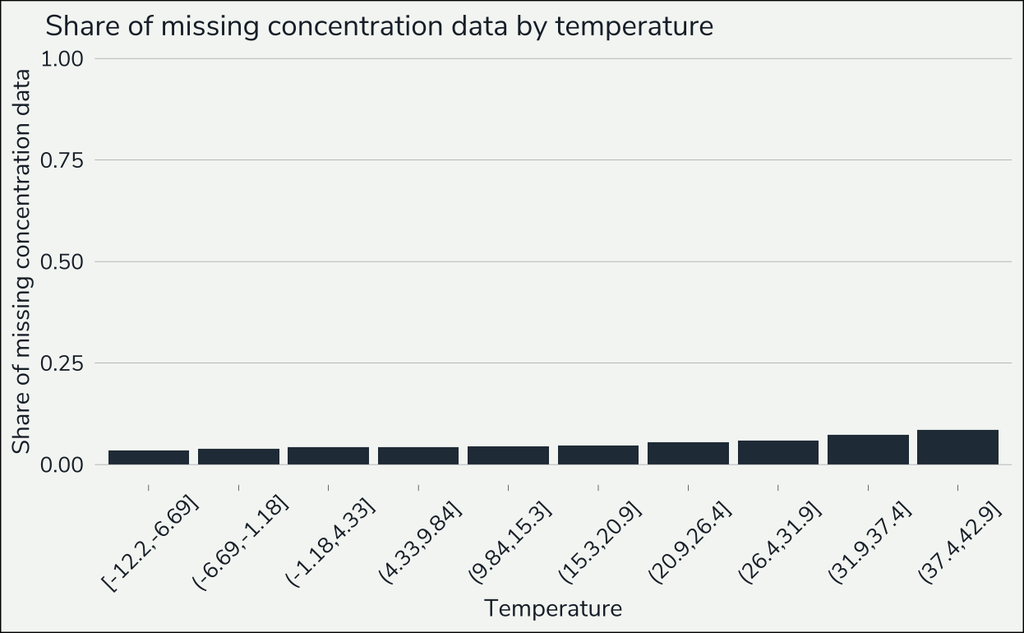